# Disciplina - DQF10443 Computação no Ensino de Física (CEF)

## Aula em 01/03/2021 (Revisada) - Semestre 2020/2 EARTE

### Prof. Roberto Colistete Jr. (RC)

### [DQF - CCENS](http://alegre.ufes.br/ccens/departamento-de-quimica-e-fisica) - [UFES/Alegre](http://alegre.ufes.br/)

# [Google Colab](https://colab.research.google.com/)

Abrindo o Google Colab (https://colab.research.google.com/), escolha menu "Arquivo -> Novo notebook" :

[figure not shown]

## Checando a configuração no Google Colab

Checando a configuração no Google Colab via alguns comandos para obter informações do sistema sendo usado.

Nome do sistema operacional, nome do computador na rede, versão do kernel, arquitetura de hardware (32/64 bits), etc :

```python
!uname -a
```

```
Linux e60a0563d525 4.19.112+ #1 SMP Thu Jul 23 08:00:38 PDT 2020 x86_64 x86_64 x86_64 GNU/Linux
```

Ou seja, Google Colab rodando [Linux kernel](https://en.wikipedia.org/wiki/Linux_kernel) [4.19.112](https://en.wikipedia.org/wiki/Linux_kernel_version_history), compilado em 23/07/2020, para 64 bits.

Nome e versão do sistema operacional :

```python
!lsb_release -a
```

```
No LSB modules are available.
Distributor ID:	Ubuntu
Description:	Ubuntu 18.04.5 LTS
Release:	18.04
Codename:	bionic
```

Ou seja, Google Colab rodando distribuição Linux [Ubuntu (Bionic) 18.04.5 LTS](https://ubuntu.com/about/release-cycle), tal versão foi [lançada em 13/08/2020 e tem suporte até Abril de 2023](https://wiki.ubuntu.com/Releases).

Diversas informações da CPU, como nome do processador, frequência em MHz da CPU, número de núcleos/cores, número de threads, memória cache, arquitetura de hardware (32/64 bits), etc :

```python
!lscpu
```

```
Architecture:        x86_64
CPU op-mode(s):      32-bit, 64-bit
Byte Order:          Little Endian
CPU(s):              2
On-line CPU(s) list: 0,1
Thread(s) per core:  2
Core(s) per socket:  1
Socket(s):           1
NUMA node(s):        1
Vendor ID:           GenuineIntel
CPU family:          6
Model:               63
Model name:          Intel(R) Xeon(R) CPU @ 2.30GHz
Stepping:            0
CPU MHz:             2299.998
BogoMIPS:            4599.99
Hypervisor vendor:   KVM
Virtualization type: full
L1d cache:           32K
L1i cache:           32K
L2 cache:            256K
L3 cache:            46080K
NUMA node0 CPU(s):   0,1
Flags:               fpu vme de pse tsc msr pae mce cx8 apic sep mtrr pge mca cmov pat pse36 clflush mmx fxsr sse sse2 ss ht syscall nx pdpe1gb rdtscp lm constant_tsc rep_good nopl xtopology nonstop_tsc cpuid tsc_known_freq pni pclmulqdq ssse3 fma cx16 pcid sse4_1 sse4_2 x2apic movbe popcnt aes xsav…
```

Ou seja, Google Drive rodando VM (Virtual Machine, Máquina Virtual) com [CPU Intel Xeon](https://ark.intel.com/content/www/br/pt/ark.html#@PanelLabel595) @ 2.30 GHz, 1 núcleo e 2 threads disponíveis, memória cache L3 de 46MB.

Ao abrir outra sessão, pode ser que a versão da CPU seja um pouco diferente, por exemplo, Intel Xeon @ 2.00 GHz ou 2.20 GHz 2.30 GHz, versão com memória cache maior ou menor, etc. Pois há várias CPU's Intel Xeon usadas pelo Google Colab.

Memória RAM total e em uso pelo sistema operacional :

```python
!free
```

```
              total        used        free      shared  buff/cache   available
Mem:       13333596      527712    10870432         984     1935452    12522160
Swap:             0           0           0
```

```python
!free -h
```

```
              total        used        free      shared  buff/cache   available
Mem:            12G        515M         10G        984K        1.8G         11G
Swap:            0B          0B          0B
```

Partições do sistema de arquivos do sistema operacional :

```python
!df -h
```

```
Filesystem      Size  Used Avail Use% Mounted on
overlay         108G   31G   78G  29% /
tmpfs            64M     0   64M   0% /dev
tmpfs           6.4G     0  6.4G   0% /sys/fs/cgroup
shm             5.9G     0  5.9G   0% /dev/shm
tmpfs           6.4G   24K  6.4G   1% /var/colab
/dev/sda1       114G   32G   83G  28% /etc/hosts
tmpfs           6.4G     0  6.4G   0% /proc/acpi
tmpfs           6.4G     0  6.4G   0% /proc/scsi
tmpfs           6.4G     0  6.4G   0% /sys/firmware
```

Partição root (/) de 108 GB disponibilizada para a VM (Virtual Machine) do Google Colab, com 31 GB sendo utilizados, ocupados pelo Ubuntu e centenas de softwares extras instalados, entre os quais vários módulos Python.

## [Repositório público "Ferramentas_Ensino_Pesquisa"](https://github.com/rcolistete/Ferramentas_Ensino_Pesquisa)

Para mais comandos de informações do sistema, vide [repositório "Ferramentas_Ensino_Pesquisa"](https://github.com/rcolistete/Ferramentas_Ensino_Pesquisa) e o [arquivo Jupyter Notebook "Informacoes_Sistema_LinuxMacOS.ipynb"](https://github.com/rcolistete/Ferramentas_Ensino_Pesquisa/blob/main/Informacoes_Sistema/Informacoes_Sistema_LinuxMacOS.ipynb), recomendado para rodar no Google Colab.

[figure not shown]

# Problema - Experimento de 2a lei de Newton e MRUV

Esse problema, com dados experimentais com incertezas, cálculos com propagação de incertezas e gráficos com barras de incerteza, visa praticar o uso de Python e módulos Uncertainties, MatPlotLib e Pandas.

## Enunciado

Um grupo de alunos realizou uma experiência sobre 2a lei de Newton e movimento retilínio uniformemente variado (MRUV), com um carrinho sendo acelerado por um peso dependurado, sobre um trilho com colchão-de-ar minimizando o atrito.

Foram feitas as medidas de posição e tempo via um sensor de distância. A posição inicial é $x_{0} = (0,000\pm 0,005)\,m$ e o instante de tempo inicial é $t_{0} = (0,000 \pm 0,005)\,s$, quando o carrinho está parado, isto é, $v_0 = 0,0\,m/s$.

1) um 1o conjunto de medições de posição $\times$ tempo do carrinho em movimento foram feitas e tabeladas :

| i | $t(s)$ | $\Delta t(s)$ | $x(m)$ | $\Delta x(m)$ |
| --- | --- | --- | --- | --- |
| 1 | 0,120 | 0,005 | 0,021 | 0,005 |
| 2 | 0,240 | 0,005 | 0,072 | 0,006 |
| 3 | 0,360 | 0,005 | 0,172 | 0,008 |
| 4 | 0,480 | 0,005 | 0,293 | 0,009 |
| 5 | 0,600 | 0,005 | 0,464 | 0,010 |

Tabela 1.

Então :

1.a) Calcule a aceleração $a_i$ para cada medição de $x_i$ e $t_i$, usando a expressão de MRUV, considerando que a aceleração é constante no movimento e $t$ é medido em relação a $t_0$ :

$$ x(t) = x_{0} + v_{0}\,(t - t_0) + \frac{a\,(t - t_0)^2}{2}$$

Use os valores de $x_{0}$ e $v_{0}$ dados para obter a aceleração $a_i$ em função da posição $x_i$ e tempo $t_i$ medidos com incertezas. Use o módulo Python Uncertainties para tanto.

1.b) Calcule então a média $a_m$ dessas acelerações $a_i$. Compare percentualmente essa aceleração média $a_m$ com a gravidade local da UFES-Alegre, $g = (9,786 \pm 0,005)\,m/s^2$.

1.c) Usando o módulo Python MatPlotLib, faça gráfico com pontos tendo barras de incerteza de :

- posição $x_i \times$ tempo $t_i$;
- aceleração $a_i \times$ tempo $t_i$.

2) Um 2o conjunto, com 42 medições de posição $\times$ tempo de uma esfera em movimento, estão no arquivo "Medidas42_posicao_tempo.csv", com colunas {${i, t(s), \Delta t(s), x(m), \Delta x(m)}$}.

2.a) Leia então os dados de tal arquivo .csv, usando módulo Python Pandas.

2.b) Mostre a tabela 1 das 5 medições de (1) via Pandas, depois mostre a tabela das 42 medições com todas as colunas, também usando módulo Pandas.

2.c) Tal como em (1.a), obtenha a aceleração $a_i$ em função das 42 posições $x_i$ e tempos $t_i$.  
Exiba uma tabela com {${i, t(s), \Delta t(s), a(m/s^2), \Delta a(m/s^2)}$}, usando Pandas.

2.d) Calcule então a média $a_m$ das 42 acelerações $a_i$.  
Compare percentualmente essa aceleração média $a_m$ com a gravidade local da UFES-Alegre, $g = (9,786 \pm 0,005)\,m/s^2$.  
Também compare percentualmente essa aceleração média $a_m$ das 42 medidas com a de 5 medidas da tabela 1.

2.e) Usando o módulo Python MatPlotLib, faça gráfico com pontos tendo barras de incerteza das 42 medidas de :

- posição $x_i$ versus tempo $t_i$;
- aceleração $a_i$ versus tempo $t_i$.

## Resolução

### Resolução analítica de (1.a), obtendo aceleração $a_i$

Partindo da expressão de MRUV, em que a aceleração $a$ é constante e $t$ é medido em relação a $t_0$ :

$$ x(t) = x_{0} + v_{0}\,(t - t_0) + \frac{a\,(t - t_0)^2}{2}$$

Como $v_{0}$ é nulo pois o carrinho estava em repouso inicialmente, e agrupando $x$ :

$$[ x(t) - x_{0}] = \frac{a\,(t - t_0)^2}{2}$$

Explicitando a aceleração $a$ :

$$ a = \frac{2\,[ x(t) - x_{0}]}{(t - t_0)^2}$$

Usando indice $i$ :

$$ a_i = \frac{2\,( x_i - x_{0})}{(t_i - t_0)^2}$$

Se o cálculo de $a_i$ com propagação de incertezas fosse feito manualmente, teria 5 cálculos manuais para cada $i$ : 2 subtrações, 1 potência, 1 divisão, 1 produto. O que gastaria várias linhas no papel para cada $i$.

### Uso do [módulo Uncertainties](https://pythonhosted.org/uncertainties/) para definir e propagar incertezas

[figure not shown]

O cálculo da aceleração $a_i$, etc, com propagação de incertezas, deve usar o módulo Python Uncertainties pois foi assim pedido no enunciado do problema.

A vantagem do módulo Python Uncertainties sobre cálculo manual de propagação de incertezas é maior eficiência : basta escrever a expressão matemática dos termos com incertezas que o resultado final é obtido com propagação automática das incertezas.

Isso poupa muito tempo e evita erros humanos nos cálculos, ainda mais quando o número de medidas é grande.

#### Instalação do módulo Uncertainties

Como o módulo Uncertainties não vem pré-instalado no Google Colab, então é necessário fazer a instalação na VM (Virtual Machine) do Google Colab rodando no Linux (Ubuntu), toda vez que uma sessão é iniciada :

```python
!pip install --upgrade uncertainties
```

```
     |████████████████████████████████| 256kB 5.3MB/s
```

#### Importação do módulo Uncertainties

Forma recomendada de importar módulo Uncertainties, segundo exemplos da [documentação oficial](https://pythonhosted.org/uncertainties/#an-easy-to-use-calculator).

Para definições de grandezas com incertezas e operações matemáticas mais simples :

```python
from uncertainties import ufloat
```

Para funções matemáticas como sqrt, sin, cos, etc, com capacidade de propagação de incertezas :

```python
from uncertainties.umath import *
```

Para um subconjunto de NumPy suportar definições com incertezas e propagação de incertezas, vide documentação ["Uncertainties in arrays"](https://pythonhosted.org/uncertainties/numpy_guide.html) :

```python
from uncertainties import unumpy
```

#### Definições de números com incertezas via módulo Uncertainties

Vide documentação ["Creating numbers with uncertainties - User Guide"](https://pythonhosted.org/uncertainties/user_guide.html#creating-numbers-with-uncertainties), basicamente se deve usar a função `ufloat(valor exato, erro)` para definir números com incertezas.

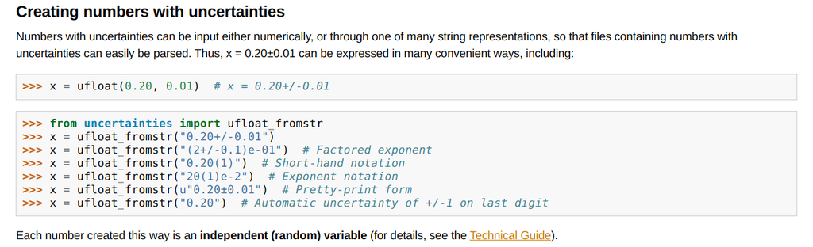

Vamos primeiramente definir $x_0$, $t_0$, $x_1$, $t_1$ com os valores dados no enunciado :

```python
x0 = ufloat(0.000, 0.005); x0
```

```
0.0+/-0.005
```

```python
t0 = ufloat(0.000, 0.005); t0
```

```
0.0+/-0.005
```

```python
x1 = ufloat(0.021, 0.005); x1
```

```
0.021+/-0.005
```

```python
t1 = ufloat(0.120, 0.005); t1
```

```
0.12+/-0.005
```

Um número com incerteza definido via `ufloat` pode ter suas partes (exata/nominal e incerteza/erro/desvio padrão) acessíveis em separado, vide documentação ["Access to the uncertainty and to the nominal value - User Guide"](https://pythonhosted.org/uncertainties/user_guide.html#access-to-the-uncertainty-and-to-the-nominal-value).

`.n` e `.nominal_value` são sinônimos para parte exata/nominal do valor com incerteza :

```python
[x1.n, x1.nominal_value]
```

```
[0.021, 0.021]
```

`.s` e `.std_dev` são sinônimos para parte de incerteza/erro/desvio padrão do valor com incerteza :

```python
[x1.s, x1.std_dev]
```

```
[0.005, 0.005]
```

#### Cálculo de $a_1$ com propagação de incertezas usando módulo Uncertainties

O cálculo de propagação de incertezas usando módulo Uncertainties é trivial, basta uma linha e o resultado final é obtido, com 15-16 algarismos.

Mas note que não é feita análise de número correto de algarismos significativos por parte do módulo Uncertainties, ao exibir o valor da variável com incerteza.

```python
a1 = 2*(x1 - x0)/((t1 - t0)**2); a1
```

```
2.916666666666667+/-1.0405086155397012
```

Porém usando saída formatada via `print()` (vide seção ["Printing - User Guide"](https://pythonhosted.org/uncertainties/user_guide.html#printing)), tem-se controle do número de algarismos significativos exibidos no valor exato/nominal e na incerteza/erro/desvio, via módulo Uncertainties :

```python
print(a1)
```

```
2.9+/-1.0
```

O que confere com o resultado com número correto de algarismos significativos, $a_1 = (2,9 \pm 1,0)\,m/s^2$, ao se considerar que incerteza deve ter no máximo 2 algarismos significativos, compondo uma dezena 'baixa' (convenção de cada um). Vide [material do Particle Data Group, seção "5.3. Rounding", pág. 13](https://pdg.lbl.gov/2010/reviews/rpp2010-rev-rpp-intro.pdf).

Embora os resultados parciais não sejam exibidos para cada operação matemática, pode-se calcular uma operação matemática por vez, por exemplo :

```python
(x1 - x0)
```

```
0.021+/-0.007071067811865475
```

```python
2*(x1 - x0)
```

```
0.042+/-0.01414213562373095
```

```python
(t1 - t0)
```

```
0.12+/-0.007071067811865475
```

```python
(t1 - t0)**2
```

```
0.0144+/-0.001697056274847714
```

Via módulo Uncertainties, cada operação matemática com incertezas não tem os cálculos passo-a-passo mostrados.

#### 1.a) Cálculo de $a_i$ com propagação de incertezas usando módulo Uncertainties e arrays (de NumPy)

Um subconjunto de NumPy suporta definições com incertezas e propagação de incertezas, vide documentação ["Uncertainties in arrays"](https://pythonhosted.org/uncertainties/numpy_guide.html).

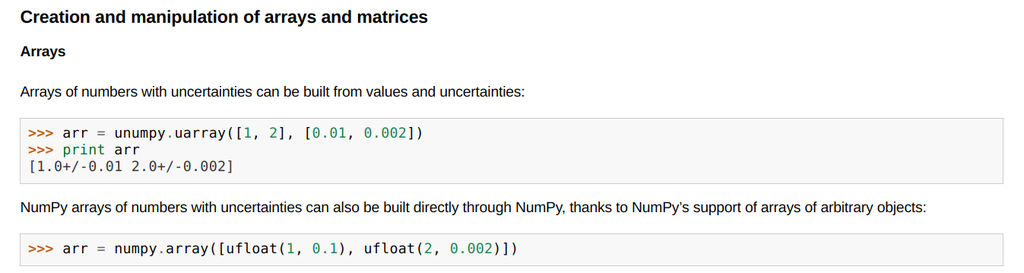

Definindo as medições de posição $X = x \pm \Delta x$ e tempo $T = t \pm \Delta t$ da tabela 1 :

```python
x = unumpy.uarray([0.021, 0.072, 0.172, 0.293, 0.464], [0.005, 0.006, 0.008, 0.009, 0.010]); x
```

```
array([0.021+/-0.005, 0.072+/-0.006, 0.172+/-0.008, 0.293+/-0.009,
       0.464+/-0.01], dtype=object)
```

```python
t = unumpy.uarray([0.120, 0.240, 0.360, 0.480, 0.600], [0.005, 0.005, 0.005, 0.005, 0.005]); t
```

```
array([0.12+/-0.005, 0.24+/-0.005, 0.36+/-0.005, 0.48+/-0.005,
       0.6+/-0.005], dtype=object)
```

Saída formatada via `print()` não exibe os elementos do array com número correto de algarismos significativos :

```python
print("x +/- dx = ", x); print("t +/- dt = ", t)
```

```
x +/- dx =  [0.021+/-0.005 0.072+/-0.006 0.172+/-0.008 0.293+/-0.009 0.464+/-0.01]
t +/- dt =  [0.12+/-0.005 0.24+/-0.005 0.36+/-0.005 0.48+/-0.005 0.6+/-0.005]
```

Mas `print()` de cada valor do array exibe com número correto de algarismos significativos :

```python
print("x[4] = ", x[4]); print("t[4] = ", t[4])
```

```
x[4] =  0.464+/-0.010
t[4] =  0.600+/-0.005
```

```python
for xi in x:
    print(xi)
```

```
0.021+/-0.005
0.072+/-0.006
0.172+/-0.008
0.293+/-0.009
0.464+/-0.010
```

```python
for ti in t:
    print(ti)
```

```
0.120+/-0.005
0.240+/-0.005
0.360+/-0.005
0.480+/-0.005
0.600+/-0.005
```

Para extrair a parte exata/nominal e a parte e incerteza/erro/desvio padrão do valor com incerteza, vide [Uncertainties and nominal values - Uncertainties in arrays](https://pythonhosted.org/uncertainties/numpy_guide.html#uncertainties-and-nominal-values) :

```python
unumpy.nominal_values(x)
```

```
array([0.021, 0.072, 0.172, 0.293, 0.464])
```

```python
unumpy.std_devs(x)
```

```
array([0.005, 0.006, 0.008, 0.009, 0.01 ])
```

```python
unumpy.nominal_values(t)
```

```
array([0.12, 0.24, 0.36, 0.48, 0.6 ])
```

```python
unumpy.std_devs(t)
```

```
array([0.005, 0.005, 0.005, 0.005, 0.005])
```

Cálculos com incertezas de vários valores podem ser feitos sem precisar usar loop, graças a NumPy com Uncertainties, aqui todos valores $x_i$ menos $x_0$ :

```python
x - x0
```

```
array([0.021+/-0.007071067811865475, 0.072+/-0.0078102496759066544,
       0.172+/-0.009433981132056603, 0.293+/-0.010295630140987,
       0.464+/-0.011180339887498949], dtype=object)
```

Tal que os valores de $a_i$ são calculados diretamente :

```python
a = 2*(x - x0)/((t - t0)**2); a
```

```
array([2.916666666666667+/-1.0405086155397012, 2.5+/-0.30861786171234684,
       2.654320987654321+/-0.17907507480887358,
       2.5434027777777777+/-0.11663052482930382,
       2.577777777777778+/-0.08688876259029057], dtype=object)
```

Algo parecido com tabela usando `print()` em Python não é muito elegante :

```python
print("i         t[i]             x[i]           a[i]")
for i in range(len(x)):
    print(i+1, "  ", t[i], "  ", x[i], "  ", a[i])
```

```
i         t[i]             x[i]           a[i]
1    0.120+/-0.005    0.021+/-0.005    2.9+/-1.0
2    0.240+/-0.005    0.072+/-0.006    2.50+/-0.31
3    0.360+/-0.005    0.172+/-0.008    2.65+/-0.18
4    0.480+/-0.005    0.293+/-0.009    2.54+/-0.12
5    0.600+/-0.005    0.464+/-0.010    2.58+/-0.09
```

Porém usando alguns módulos Python de manipulação de dados fica mais fácil, por exemplo, [módulo Pandas](https://pandas.pydata.org/) a ser visto em breve.

#### 1.b) Cálculo de média $a_m$ usando módulo Uncertainties e arrays

Para calcular a média $a_m$ das acelerações $a_i$, precisamos usar módulo NumPy.  
Já que `unumpy` não tem `mean()`.

Importando o módulo NumPy, sendo 'np' um apelido comum :

```python
import numpy as np
```

```python
am = np.mean(a); am
```

```
2.6384336419753085+/-0.27787447063346615
```

```python
print(am)
```

```
2.64+/-0.28
```

Para comparar percentualmente a aceleração média $a_m$ com a gravidade local da UFES-Alegre, $g = (9,786 \pm 0,005)\,m/s^2$ :

```python
g = ufloat(9.786, 0.005); g
```

```
9.786+/-0.005
```

```python
print("a_m / g = (", 100*am/g, ")%")
```

```
a_m / g = ( 27.0+/-2.8 )%
```

### 1.c) Usando [MatPlotLib](https://matplotlib.org/) para gráficos de pontos com barras de incerteza

Queremos via módulo Python MatPlotLib fazer os gráfico com pontos tendo barras de incerteza de :

- posição $x_i \times$ tempo $t_i$;
- aceleração $a_i \times$ tempo $t_i$.

Há [diferentes formas recomendadas de importar MatPlotLib para uso em Jupyter Notebook, Google Colab, etc](https://medium.com/@Med1um1/using-matplotlib-in-jupyter-notebooks-comparing-methods-and-some-tips-python-c38e85b40ba1).

- com o magic command `%matplotlib notebook` do Jupyter Notebook, que permite interagir com o gráfico gerado, ampliando/reduzindo, transladando, etc. Mas só pode ter um gráfico ativo no modo interativo por vez, então tem que desativar (clique no botão azul no canto superior direito) o último gráfico interativo para calcular o seguinte (senão sobrepõe e fica bagunçado). É **atualmente incompatível com Google Colab**;
- com o magic command [`%matplotlib inline`](https://jakevdp.github.io/PythonDataScienceHandbook/04.00-introduction-to-matplotlib.html#Plotting-from-an-IPython-notebook) do Jupyter Notebook, que embute o gráfico gerado no Jupyter Notebook, sem recursos de interatividade. Recomendado para gerar vários gráficos em sequência em um Jupyter Notebook, sem interação humana durante a execução, bem como ao usar Google Colab.

Usaremos o magic command `%matplotlib inline`, mudando o tamanho do gráfico inline/embutido via [`plt.rcParams['figure.figsize'] = [10, 6]`](https://matplotlib.org/stable/api/_as_gen/matplotlib.pyplot.figure.html#matplotlib-pyplot-figure) (ou outro tamanho horizontal e vertical em polegadas), pois é default é gráfico pequeno (6.4 e 4.8 polegadas).

```python
# %matplotlib notebook
%matplotlib inline
import matplotlib.pyplot as plt
plt.rcParams['figure.figsize'] = [10, 6]
```

O [módulo MatPlotLib tem vários tipos de gráficos](https://matplotlib.org/stable/gallery/index.html), um deles permite ter pontos com barras de incerteza, vide função ["matplotlib.pyplot.errorbar() - MatPlotLib"](https://matplotlib.org/stable/api/_as_gen/matplotlib.pyplot.errorbar.html) e exemplos :

- [Errorbar function - MatPlotLib](https://matplotlib.org/stable/gallery/statistics/errorbar.html);
- [Different ways of specifying error bars - MatPlotLib](https://matplotlib.org/stable/gallery/statistics/errorbar_features.html);
- [Including upper and lower limits in error bars - MatPlotLib](https://matplotlib.org/stable/gallery/statistics/errorbar_limits.html).
- [Matplotlib.pyplot.errorbar() in Python - GeeksforGeeks](https://www.geeksforgeeks.org/matplotlib-pyplot-errorbar-in-python/);
- [Visualizing Errors - Python Data Science Handbook by Jake VanderPlas](https://colab.research.google.com/github/jakevdp/PythonDataScienceHandbook/blob/master/notebooks/04.03-Errorbars.ipynb).

Temos que extrair os valores exatos/nominais e de incerteza/erro/desvio padrão para arrays (do NumPy) separados :

```python
x_n = unumpy.nominal_values(x); x_n
```

```
array([0.021, 0.072, 0.172, 0.293, 0.464])
```

```python
x_e = unumpy.std_devs(x); x_e
```

```
array([0.005, 0.006, 0.008, 0.009, 0.01 ])
```

```python
t_n = unumpy.nominal_values(t); t_n
```

```
array([0.12, 0.24, 0.36, 0.48, 0.6 ])
```

```python
t_e = unumpy.std_devs(t); t_e
```

```
array([0.005, 0.005, 0.005, 0.005, 0.005])
```

```python
a_n = unumpy.nominal_values(a); a_n
```

```
array([2.91666667, 2.5       , 2.65432099, 2.54340278, 2.57777778])
```

```python
a_e = unumpy.std_devs(a); a_e
```

```
array([1.04050862, 0.30861786, 0.17907507, 0.11663052, 0.08688876])
```

#### Gráfico de posição $x_i \times$ tempo $t_i$

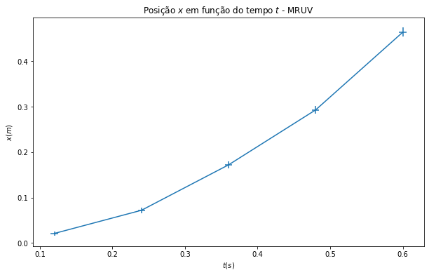

```python
#plt.plot(t_n, x_n)
plt.errorbar(t_n, x_n, xerr = t_e, yerr = x_e)
plt.title(r'Posição $x$ em função do tempo $t$ - MRUV')
plt.xlabel(r'$t(s)$'); plt.ylabel(r'$x(m)$')
plt.show()
```

A FAZER (alunos fizeram como exercício durante a aula, pesquisando em documentação, etc) :

- mudar tamanho do gráfico; (alguns alunos fizeram)
- grade (grid) de fundo;
- mudar estilo da linha; (alguns alunos fizeram)
- mudar cor da linha; (alguns alunos fizeram)
- mudar cor de fundo; (alguns alunos fizeram)

#### Gráfico de aceleração $a_i \times$ tempo $t_i$.

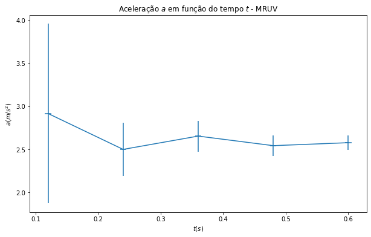

```python
#plt.plot(t_n, a_n)
plt.errorbar(t_n, a_n, xerr = t_e, yerr = a_e)
plt.title(r'Aceleração $a$ em função do tempo $t$ - MRUV')
plt.xlabel(r'$t(s)$'); plt.ylabel(r'$a(m/s^2)$')
plt.show()
```

A FAZER (alunos fizeram como exercício durante a aula, pesquisando em documentação, etc) :

- escolher escala vertical começando de 0 m/s^2; (alguns alunos fizeram)
- mudar tamanho do gráfico; (alguns alunos fizeram)
- grade (grid) de fundo;
- mudar estilo da linha; (alguns alunos fizeram)
- mudar cor da linha; (alguns alunos fizeram)
- mudar cor de fundo; (alguns alunos fizeram)

### Usando [Pandas](https://pandas.pydata.org/) para manipulação e análise de dados

O módulo Pandas permite fazer facilmente manipulação e análise de dados, com [leitura/gravação de diferentes formatos de arquivos](https://pandas.pydata.org/pandas-docs/stable/user_guide/io.html) : CSV, Microsoft Excel, HTML, HDF5, JSON, Stata, SPSS, SQL, etc.

Tem muita documentação, tutoriais, etc, oficiais e da comunidade, sobre Pandas, por exemplo :

- [Getting Started/Começando - Pandas](https://pandas.pydata.org/pandas-docs/stable/getting_started/index.html);
- [User Guide/Guia do Usuário - Pandas](https://pandas.pydata.org/pandas-docs/stable/user_guide/index.html);
- [Seus primeiros passos como Data Scientist: Introdução ao Pandas! - Vinícius Figueiredo - Medium.com](https://medium.com/data-hackers/uma-introdu%C3%A7%C3%A3o-simples-ao-pandas-1e15eea37fa1). Vide no início arquivo Jupyter Notebook (visualizável via Binder ou notebook viewer (nbviewwer), recomendável para praticar.
- [Pandas Tutorial - w3schools.com](https://www.w3schools.com/python/pandas/default.asp)
- [Pandas Basic - learningpython](https://www.learnpython.org/en/Pandas_Basics)

#### Usando arquivo de 5 medidas de MRUV em movimento

Tal arquivo "Medidas5_posicao_tempo.csv" será importado para o sistema de arquivos da VM (máquina virtual) do Google Colab. Há diferentes formas de fazer isso, uma delas é usar [comando Linux `'wget'`](https://terminalroot.com.br/2019/05/aprenda-a-explorar-o-comando-wget.html) seguido do endereço Internet do arquivo.

O endereço Internet do arquivo .csv no repositório deve ser obtido após clicar uma vez no arquivo .csv, quando o mesmo é visualizado, e depois clicar no botão "Raw" na barra superior direita :

[figure not shown]

```python
!wget https://raw.githubusercontent.com/rcolistete/Computacao_no_Ensino_de_Fisica_UFES_Alegre/main/Aulas/Aula_20210301/Medidas5_posicao_tempo.csv
```

```
--2021-03-02 16:14:23--  https://raw.githubusercontent.com/rcolistete/Computacao_no_Ensino_de_Fisica_UFES_Alegre/main/Aulas/Aula_20210301/Medidas5_posicao_tempo.csv
Resolving raw.githubusercontent.com (raw.githubusercontent.com)... 185.199.108.133, 185.199.109.133, 185.199.110.133, ...
Connecting to raw.githubusercontent.com (raw.githubusercontent.com)|185.199.108.133|:443... connected.
HTTP request sent, awaiting response... 200 OK
Length: 180 [text/plain]
Saving to: ‘Medidas5_posicao_tempo.csv’

Medidas5_posicao_te 100%[===================>]     180  --.-KB/s    in 0s

2021-03-02 16:14:23 (4.71 MB/s) - ‘Medidas5_posicao_tempo.csv’ saved [180/180]
```

##### Comandos mágicos (magic commands) de IPython/Jupyter Notebook

Usando [comandos mágicos (magic commands) de IPython/Jupyter Notebook](https://ipython.readthedocs.io/en/stable/interactive/magics.html#), temos várias funcionalidades extras. São vários :

```python
%lsmagic
```

```
Available line magics:
%alias  %alias_magic  %autocall  %automagic  %autosave  %bookmark  %cat  %cd  %clear  %colors  %config  %connect_info  %cp  %debug  %dhist  %dirs  %doctest_mode  %ed  %edit  %env  %gui  %hist  %history  %killbgscripts  %ldir  %less  %lf  %lk  %ll  %load  %load_ext  %loadpy  %logoff  %logon  %logstar…

Available cell magics:
%%!  %%HTML  %%SVG  %%bash  %%bigquery  %%capture  %%debug  %%file  %%html  %%javascript  %%js  %%latex  %%perl  %%prun  %%pypy  %%python  %%python2  %%python3  %%ruby  %%script  %%sh  %%shell  %%svg  %%sx  %%system  %%time  %%timeit  %%writefile

Automagic is ON, % prefix IS NOT needed for line magics.
```

'`%ls`' lista o diretório atual no computador (ou VM, máquina virtual rodando no Google Colab), aqui com opção `-l` para listar detalhes :

```python
%ls -l
```

```
total 8
-rw-r--r-- 1 root root  180 Mar  2 22:18 Medidas5_posicao_tempo.csv
drwxr-xr-x 1 root root 4096 Mar  1 14:35 sample_data/
```

Outra opção para listar o diretório do usuário no sistema de arquivos é via [comando Linux `'ls'`](https://www.vivaolinux.com.br/artigo/O-comando-LS-de-A-a-Z), mas não funciona em Windows :

```python
!ls -l
```

```
total 8
-rw-r--r-- 1 root root  180 Mar  2 22:18 Medidas5_posicao_tempo.csv
drwxr-xr-x 1 root root 4096 Mar  1 14:35 sample_data
```

Como o arquivo .csv é no formato texto legível, podemos ler o conteúdo dele via comandos de terminal.

Aqui via comando mágico '`%cat`' :

```python
%cat Medidas5_posicao_tempo.csv
```

```
0, 0.000, 0.005, 0.000, 0.005
1, 0.120, 0.005, 0.021, 0.005
2, 0.240, 0.005, 0.072, 0.006
3, 0.360, 0.005, 0.172, 0.008
4, 0.480, 0.005, 0.293, 0.009
5, 0.600, 0.005, 0.464, 0.010
```

Ou usando diretamente o [comando Linux `'cat'`](https://www.linuxforce.com.br/comandos-linux/comandos-linux-comando-cat/), mas não funciona em Windows :

```python
!cat Medidas5_posicao_tempo.csv
```

```
0, 0.000, 0.005, 0.000, 0.005
1, 0.120, 0.005, 0.021, 0.005
2, 0.240, 0.005, 0.072, 0.006
3, 0.360, 0.005, 0.172, 0.008
4, 0.480, 0.005, 0.293, 0.009
5, 0.600, 0.005, 0.464, 0.010
```

[Importando módulo Python Pandas](https://pandas.pydata.org/pandas-docs/stable/user_guide/10min.html#minutes-to-pandas)

Pandas vem pré-instalado no Google Colab e no Anaconda, então é trivial importar. Aqui usamos o apelido 'pd' que é muito comum :

```python
import pandas as pd
```

Para ler o arquivo "Medidas5_posicao_tempo.csv", basta usar [a função '`read_csv()`'](https://pandas.pydata.org/pandas-docs/stable/reference/api/pandas.read_csv.html#pandas.read_csv), que cria um 'dataframe' (estrutura de dados, tipo tabela) :

```python
tabela5medidas = pd.read_csv("Medidas5_posicao_tempo.csv")
```

Para exibir na tela a tabela (dataframe) formatada com os dados importados do arquivo, basta mostrar o valor da variável :

```python
tabela5medidas
```

|  | 0 | 0.000 | 0.005 | 0.000.1 | 0.005.1 |
| --- | --- | --- | --- | --- | --- |
| 0 | 1 | 0.12 | 0.005 | 0.021 | 0.005 |
| 1 | 2 | 0.24 | 0.005 | 0.072 | 0.006 |
| 2 | 3 | 0.36 | 0.005 | 0.172 | 0.008 |
| 3 | 4 | 0.48 | 0.005 | 0.293 | 0.009 |
| 4 | 5 | 0.60 | 0.005 | 0.464 | 0.010 |

Como o arquivo .csv não tinha primeira linha com rótulos (nomes) das colunas, então Pandas usou a 1a linha de dados numéricos como se fossem rótulos da tabela.

Mas no caso de arquivo sem linha de rótulos (labels) podemos explicitamente listar os rótulos via opção 'name' da [função '`read_csv()`'](https://pandas.pydata.org/pandas-docs/stable/reference/api/pandas.read_csv.html#pandas.read_csv) :

```python
tabela5medidas = pd.read_csv("Medidas5_posicao_tempo.csv", names = ["i", "t", "Dt", "x", "Dx"])
```

```python
tabela5medidas
```

|  | i | t | Dt | x | Dx |
| --- | --- | --- | --- | --- | --- |
| 0 | 0 | 0.00 | 0.005 | 0.000 | 0.005 |
| 1 | 1 | 0.12 | 0.005 | 0.021 | 0.005 |
| 2 | 2 | 0.24 | 0.005 | 0.072 | 0.006 |
| 3 | 3 | 0.36 | 0.005 | 0.172 | 0.008 |
| 4 | 4 | 0.48 | 0.005 | 0.293 | 0.009 |
| 5 | 5 | 0.60 | 0.005 | 0.464 | 0.010 |

Outra opção é ter o arquivo .csv com primeira linha tendo os rótulos (nomes) das colunas tal que Pandas usa a 1a linha de dados como rótulos da tabela.

Aqui usamos leitura de arquivo na Internet diretamente via [função '`read_csv()`'](https://pandas.pydata.org/pandas-docs/stable/reference/api/pandas.read_csv.html#pandas.read_csv) :

```python
tabela5medidas = pd.read_csv("https://raw.githubusercontent.com/rcolistete/Computacao_no_Ensino_de_Fisica_UFES_Alegre/main/Aulas/Aula_20210301/Medidas5_posicao_tempo_rotulos.csv")
```

```python
tabela5medidas
```

|  | i | t | Dt | x | Dx |
| --- | --- | --- | --- | --- | --- |
| 0 | 0 | 0.00 | 0.005 | 0.000 | 0.005 |
| 1 | 1 | 0.12 | 0.005 | 0.021 | 0.005 |
| 2 | 2 | 0.24 | 0.005 | 0.072 | 0.006 |
| 3 | 3 | 0.36 | 0.005 | 0.172 | 0.008 |
| 4 | 4 | 0.48 | 0.005 | 0.293 | 0.009 |
| 5 | 5 | 0.60 | 0.005 | 0.464 | 0.010 |

Há vários comandos/funções para listar propriedades de um dataframe. Uma função/método bem completa é ['`info()`'](https://pandas.pydata.org/pandas-docs/stable/reference/api/pandas.DataFrame.info.html), listando :

- o número de colunas;
- rótulo de cada coluna;
- número de elementos de cada coluna;
- tipo de dado de cada coluna (número inteiro, número real de ponto flutuante ou texto);
- memória RAM usada pela dataframe.

```python
tabela5medidas.info()
```

```
<class 'pandas.core.frame.DataFrame'>
RangeIndex: 6 entries, 0 to 5
Data columns (total 5 columns):
 #   Column  Non-Null Count  Dtype
---  ------  --------------  -----
 0   i       6 non-null      int64
 1   t       6 non-null      float64
 2   Dt      6 non-null      float64
 3   x       6 non-null      float64
 4   Dx      6 non-null      float64
dtypes: float64(4), int64(1)
memory usage: 368.0 bytes
```

A função/método ['`describe()`'](https://pandas.pydata.org/pandas-docs/stable/reference/api/pandas.DataFrame.describe.html) calcula estatística descritiva dos valores numéricos da tabela/dataframe, relativos aos elementos numéricos de cada coluna :

- número de elementos;
- média;
- desvio padrão;
- mínimo;
- 25% percentil, 50% percentil (mediana), 75% percentil;
- máximo.

```python
tabela5medidas.describe()
```

|  | i | t | Dt | x | Dx |
| --- | --- | --- | --- | --- | --- |
| count | 6.000000 | 6.000000 | 6.000 | 6.000000 | 6.000000 |
| mean | 2.500000 | 0.300000 | 0.005 | 0.170333 | 0.007167 |
| std | 1.870829 | 0.224499 | 0.000 | 0.180152 | 0.002137 |
| min | 0.000000 | 0.000000 | 0.005 | 0.000000 | 0.005000 |
| 25% | 1.250000 | 0.150000 | 0.005 | 0.033750 | 0.005250 |
| 50% | 2.500000 | 0.300000 | 0.005 | 0.122000 | 0.007000 |
| 75% | 3.750000 | 0.450000 | 0.005 | 0.262750 | 0.008750 |
| max | 5.000000 | 0.600000 | 0.005 | 0.464000 | 0.010000 |

Para [selecionar colunas de um dataframe/tabela](https://pandas.pydata.org/pandas-docs/stable/user_guide/10min.html#getting), basta usar os rótulos como índice :

```python
tabela5medidas["t"]
```

```
0    0.00
1    0.12
2    0.24
3    0.36
4    0.48
5    0.60
Name: t, dtype: float64
```

```python
tabela5medidas["x"]
```

```
0    0.000
1    0.021
2    0.072
3    0.172
4    0.293
5    0.464
Name: x, dtype: float64
```

Selecionando mais de uma coluna, basta usar uma lista de rótulos :

```python
tabela5medidas[["t", "Dt"]]
```

|  | t | Dt |
| --- | --- | --- |
| 0 | 0.00 | 0.005 |
| 1 | 0.12 | 0.005 |
| 2 | 0.24 | 0.005 |
| 3 | 0.36 | 0.005 |
| 4 | 0.48 | 0.005 |
| 5 | 0.60 | 0.005 |

```python
tabela5medidas[["x", "Dx"]]
```

|  | x | Dx |
| --- | --- | --- |
| 0 | 0.000 | 0.005 |
| 1 | 0.021 | 0.005 |
| 2 | 0.072 | 0.006 |
| 3 | 0.172 | 0.008 |
| 4 | 0.293 | 0.009 |
| 5 | 0.464 | 0.010 |

Selecionar linhas pode ser semelhante a NumPy, pois [Pandas suporta slices (índices començam de zero)](https://pandas.pydata.org/pandas-docs/stable/user_guide/indexing.html#slicing-ranges).

Por exemplo, listando as 2 primeiras linhas de dados (os rótulos não contam) :

```python
tabela5medidas[0:2]
```

|  | i | t | Dt | x | Dx |
| --- | --- | --- | --- | --- | --- |
| 0 | 0 | 0.00 | 0.005 | 0.000 | 0.005 |
| 1 | 1 | 0.12 | 0.005 | 0.021 | 0.005 |

Listando as 2 últimas linhas de dados :

```python
tabela5medidas[-2:]
```

|  | i | t | Dt | x | Dx |
| --- | --- | --- | --- | --- | --- |
| 4 | 4 | 0.48 | 0.005 | 0.293 | 0.009 |
| 5 | 5 | 0.60 | 0.005 | 0.464 | 0.010 |

[Selecionando linhas/colunas via posições](https://pandas.pydata.org/pandas-docs/stable/user_guide/10min.html#selection-by-position) com [`iloc`](https://pandas.pydata.org/pandas-docs/stable/reference/api/pandas.DataFrame.iloc.html) e [`iat`](https://pandas.pydata.org/pandas-docs/stable/reference/api/pandas.DataFrame.iat.html#pandas.DataFrame.iat).

Por exemplo, listando as linhas 1 e 3 de dados (os rótulos não contam) :

```python
tabela5medidas.iloc[[1,3]]
```

|  | i | t | Dt | x | Dx |
| --- | --- | --- | --- | --- | --- |
| 1 | 1 | 0.12 | 0.005 | 0.021 | 0.005 |
| 3 | 3 | 0.36 | 0.005 | 0.172 | 0.008 |

Listando as 2 últimas linhas de dados e as colunas 2 e 4 :

```python
tabela5medidas.iloc[-2:, [2,4]]
```

|  | Dt | Dx |
| --- | --- | --- |
| 4 | 0.005 | 0.009 |
| 5 | 0.005 | 0.010 |

[Convertendo Pandas dataframe / tabela para NumPy arrays](https://pandas.pydata.org/pandas-docs/stable/user_guide/10min.html#viewing-data) :

- dataframe/tabela inteira :

```python
tabela5medidas.to_numpy()
```

```
array([[0.   , 0.   , 0.005, 0.   , 0.005],
       [1.   , 0.12 , 0.005, 0.021, 0.005],
       [2.   , 0.24 , 0.005, 0.072, 0.006],
       [3.   , 0.36 , 0.005, 0.172, 0.008],
       [4.   , 0.48 , 0.005, 0.293, 0.009],
       [5.   , 0.6  , 0.005, 0.464, 0.01 ]])
```

- seleção de colunas :

```python
tabela5medidas["x"].to_numpy()
```

```
array([0.   , 0.021, 0.072, 0.172, 0.293, 0.464])
```

Pandas usa MatPlotLib para fazer gráficos de forma bem prática.

Por isso precisa importar MatPlotLib antes.

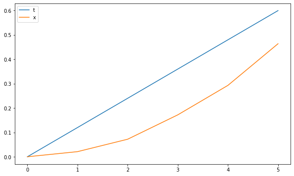

```python
tabela5medidas[["t", "x"]].plot();
```

O que falta ?

- como adicionar colunas a um dataframe, novo ou pré-existente; (desafio)
- aplicar para resolver os ítens (2.a) a (2.e) do enunciado de MRUV com arquivo de 42 medições feitas em movimento; (próxima aula)